# Patho FFPE human tumor vs. normal pancreas (AS1000Cov50, physeq_original)

Nina & Christoph

Report created: 2022-12-20

Adapter by Linh

# Combining Phyloseq objects

## Loading all physeq-objects

Run by run was separately analysed and a phyloseq object per run was created. By using a barplot for microbial composition and the beta diversity (weighted UF) outliers are detected per each run. Every outlier is categorized and a reason is described, why we identify this sample as an outlier.

```r
Path2PhyloSeqObj <- "../../raw_data/PhyloSeqObj_2/"
physeq1 <- readRDS(paste0(Path2PhyloSeqObj,"2022_05_27_patho_FFPE_tum_panc_1/physeq_original_1500.80.rds"))
physeq2 <- readRDS(paste0(Path2PhyloSeqObj,"2022_05_27_patho_FFPE_tum_panc_2/physeq_original_1500.80.rds"))
physeq3 <- readRDS(paste0(Path2PhyloSeqObj,"2022_05_28_patho_FFPE_tum_panc_3/physeq_original_1500.80.rds"))
physeq4 <- readRDS(paste0(Path2PhyloSeqObj,"2022_05_28_patho_FFPE_tum_panc_4/physeq_original_1500.80.rds"))

p.true.original <- merge_phyloseq(physeq1,physeq2,physeq3,physeq4)
```

Now, we have **48 samples and 1087 taxa**.

## Implement samples from establishment experiment (patho_ffpe_self)

n=6 FFPE tumor tissue samples (without matching normal pancreas).

```r
physeq5 <- readRDS(paste0(Path2PhyloSeqObj,"2021_12_01_patho_FFPE_self_tumor/physeq_original_1500.80.rds"))

# sample_data(physeq5)

physeq5sub <- subset_samples(physeq5, sample_nr!="P19269-20" & sample_nr!="P15970-20" & sample_nr!="P12758-20" & sample_nr!="P3434-20")

# sample_data(physeq5sub)

p.true.original <- merge_phyloseq(p.true.original,physeq5sub)

## clean objects
rm(list = c("physeq1", "physeq2", "physeq3", "physeq4", "physeq5", "physeq5sub"))
# sample_data(physeq)
```

Now in true samples, we have:

```r
sample_data(p.true.original) %>% pull(sample_side) %>% table()
```

```
## .
## normal  tumor
##     24     30
```

We have **54 samples and 1679 taxa**. ## Loading all negative control (NCT)

```r
physeq.nct1 <- readRDS(paste0(Path2PhyloSeqObj,"2022_06_02_patho_FFPE_tum_panc_ntc_1/physeq_original_1500.80.rds"))
physeq.nct2 <- readRDS(paste0(Path2PhyloSeqObj,"2022_06_02_patho_FFPE_tum_panc_ntc_2/physeq_original_1500.80.rds"))
physeq.nct3 <- readRDS(paste0(Path2PhyloSeqObj,"2022_06_03_patho_FFPE_tum_panc_ntc_3/physeq_original_1500.80.rds"))
physeq.nct4 <- readRDS(paste0(Path2PhyloSeqObj,"2022_06_03_patho_FFPE_tum_panc_ntc_4/physeq_original_1500.80.rds"))
physeq.nct5 <- readRDS(paste0(Path2PhyloSeqObj,"2022_06_04_patho_FFPE_tum_panc_ntc_5/physeq_original_1500.80.rds"))
physeq.nct6 <- readRDS(paste0(Path2PhyloSeqObj,"2022_06_04_patho_FFPE_tum_panc_ntc_6/physeq_original_1500.80.rds"))
physeq.nct7 <- readRDS(paste0(Path2PhyloSeqObj,"2022_06_10_patho_FFPE_tum_panc_ntc_7/physeq_original_1500.80.rds"))
physeq.nct8 <- readRDS(paste0(Path2PhyloSeqObj,"2022_07_13_patho_FFPE_tum_panc_ntc_8/physeq_original_1500.80.rds"))
physeq.nct9 <- readRDS(paste0(Path2PhyloSeqObj,"2022_07_13_patho_FFPE_tum_panc_ntc_9/physeq_original_1500.80.rds"))
physeq.nct10 <- readRDS(paste0(Path2PhyloSeqObj,"2021_12_02_patho_FFPE_self_ntc/physeq_original_1500.80.rds"))
physeq.nct11 <- readRDS(paste0(Path2PhyloSeqObj,"2022_01_24_patho_FFPE_self_ntc_2/physeq_original_1500.80.rds"))

physeq.nct.original <- merge_phyloseq(physeq.nct1, physeq.nct2, physeq.nct3, physeq.nct4, physeq.nct5, physeq.nct6, physeq.nct7, physeq.nct8, physeq.nct9, physeq.nct10, physeq.nct11)

rm(list = c('physeq.nct1', 'physeq.nct2', 'physeq.nct3', 'physeq.nct4', 'physeq.nct5',
            'physeq.nct6', 'physeq.nct7', 'physeq.nct8', 'physeq.nct9', 'physeq.nct10', 'physeq.nct11'))
```

Now, in NCT samples, we have:

```r
sample_data(physeq.nct.original) %>% pull(sample_side) %>% table()
```

```
## .
##          buffer        paraffin paraffin_normal  paraffin_tumor    PCR_ctrl_H2O
##              12               9              24              23               7
```

with **75 samples and 1101 taxa**. # Filtering, Removing contamination, and Normalization

## Overview

In order to normalize the data we use used 5 methods:

The first one was already applied during “phyloseq-object-creation” for every single run. Hereby, less abundant taxa were considered as technical/ bioinformatical mistakes rather than true species. The underlying algorithm was the simultanous method. Here we apply the PERfect packge again to eliminate more taxa.

To decontaminate the TRUE samples decontam is applied. The Negative controls derived from DNA-extraction (blank swab medium was extracted) and library preparation for both approaches (16S rRNA and metagenomics).

## Filtering - keep only bacterial reads

We keep only bacterial reads with resolution to species.

Filtering bacterial reads for true sample.

```r
p.true.filt <- subset_taxa(p.true.original, superkingdom=="Bacteria")
p.true.filt.s <- tax_glom(p.true.filt, taxrank = "species", NArm = TRUE)

rm(p.true.filt)
```

Now in true sample, we have 54 samples and 880 taxa.

Filtering bacterial reads for NTC samples.

```r
physeq.nct.filt <- subset_taxa(physeq.nct.original, superkingdom=="Bacteria")
physeq.nct.filt.s <- tax_glom(physeq.nct.filt, taxrank = "species", NArm = TRUE)
```

Now, in NTC samples, we have 75 samples and 586 taxa.

Overlapping of taxa between true samples and NTC samples.

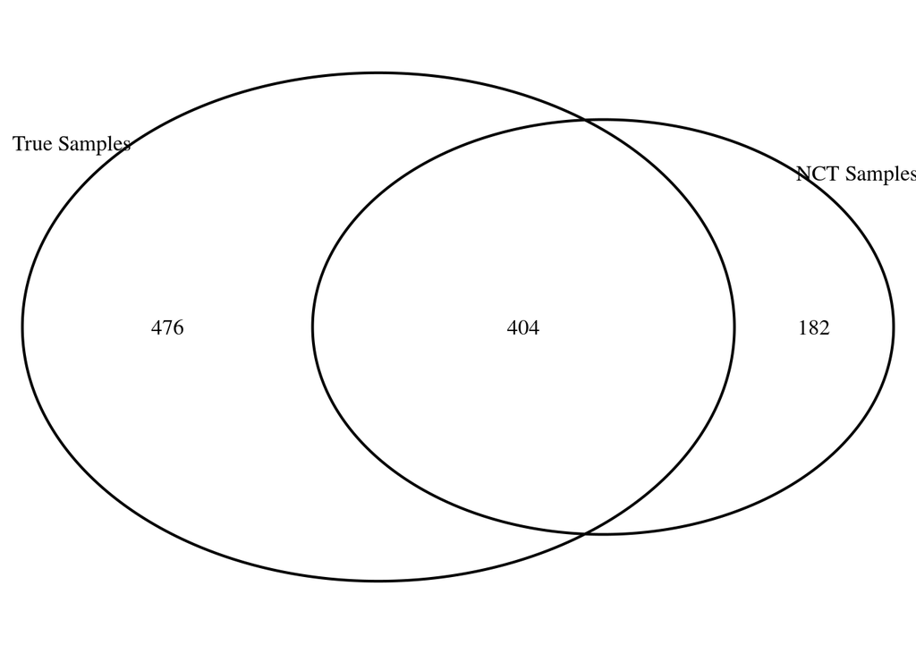

```r
set_taxa_p.true.filt.s <- row.names(otu_table(p.true.filt.s)) %>% unique()
set_taxa_physeq.nct.filt.s <- row.names(otu_table(physeq.nct.filt.s)) %>% unique()
## draw Venn diagram
library(RColorBrewer)
myCol <- brewer.pal(3, "Pastel2")[1:2]
plt <- venn.diagram(
        x = list(set_taxa_p.true.filt.s, set_taxa_physeq.nct.filt.s),
        category.names = c("True Samples" , "NCT Samples "),
        filename = NULL
)
grid::grid.newpage()
grid::grid.draw(plt)
```

## Low Abundance filtering

Remove taxa from true sample (and NCT samples???, I have not done with NCT samples) if their abundance are too low, either by a threshold 10^-4 or by PERfect package. In this example, I choose to use PERfect package.

```r
p.true.RmLowAbun <- Wrapper_FERfect(p.true.filt.s)
```

Now we have 54 samples and 685 taxa.

To control, let us check the taxa overlap between NCT samples and true sample after PERfect.

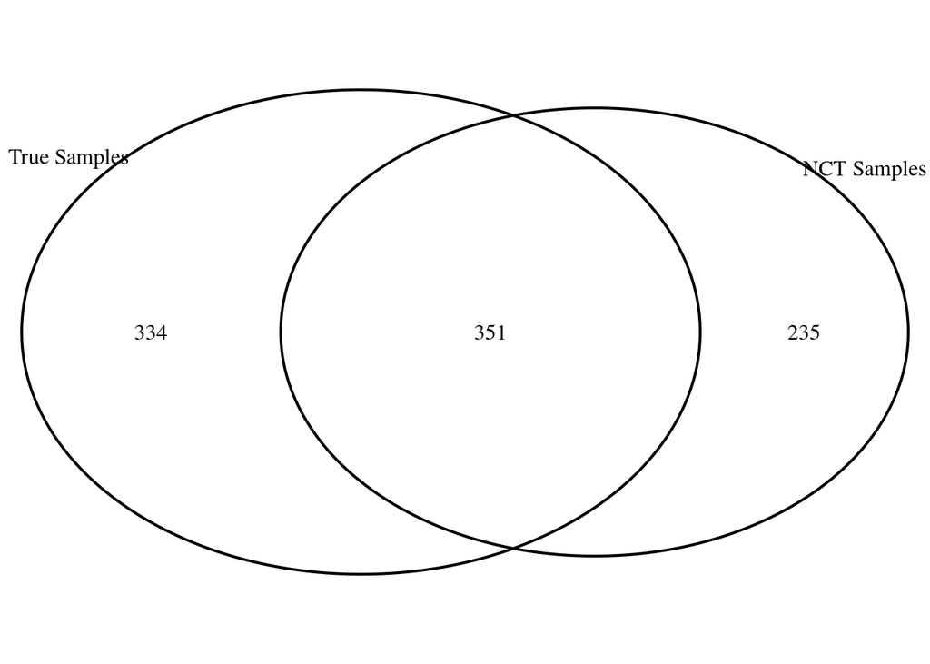

```r
plt <- venn.diagram(
        x = list(row.names(otu_table(p.true.RmLowAbun)) %>% unique(), row.names(otu_table(physeq.nct.filt.s)) %>% unique()),
        category.names = c("True Samples" , "NCT Samples "),
        filename = NULL
)
grid::grid.newpage()
grid::grid.draw(plt)
```

There are 235 taxa belong to NCT samples but not in true samples (after PERfect). They are obvious contamination. Thus we prune them from NCT samples

```r
set_taxa_intersect_nct <-  intersect(row.names(otu_table(p.true.RmLowAbun)) %>% unique(), row.names(otu_table(physeq.nct.filt.s)) %>% unique())
physeq.nct.filt.s.prune <- prune_taxa(set_taxa_intersect_nct, physeq.nct.filt.s)
```

## Filtering by Prevalence

We following the procudure from Nejman et al. 2020, which comprises two steps:

### High prevalence filering

Any tax which has high prevalence (>= a threshold) in NCT samples is considered as contamination. First, we plot a graph to determine the cut-off of high prevalence.

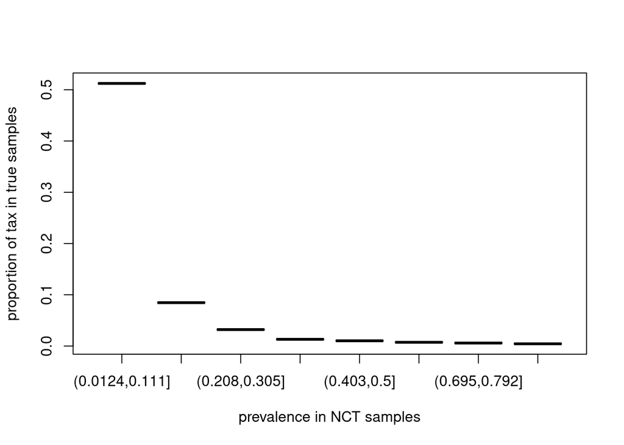

```r
xout <- HighPrevalence_Data(p.true.RmLowAbun, physeq.nct.filt.s.prune)
plot(xout$factorx, xout$rel_tax, xlab="prevalence in NCT samples", ylab="proportion of tax in true samples")
```

This plot shows us how many percents of taxa we would remove from true samples (y-axis) if we pick up a threshold for high prevalence in NCT samples (x-axis). From this plot, a threshold 0.3 would be fine.

```r
filter <- 0.3
filtered_taxa1 <- tibble(
  Cont = genefilter_sample(physeq.nct.filt.s.prune, filterfun_sample(function(x) x > 0), A=filter*nsamples(physeq.nct.filt.s.prune)),
  OTU = names(genefilter_sample(physeq.nct.filt.s.prune, filterfun_sample(function(x) x > 0), A=filter*nsamples(physeq.nct.filt.s.prune)))
) %>%
  arrange (-Cont)

cont.count <- filtered_taxa1 %>% count(Cont)
cont.count %>%
  kable (caption=paste("Count of contaminants (filter", filter*100, " %)"), booktabs =TRUE) %>%
  kable_classic(full_width = F, html_font = "Cambria") %>%
  kable_styling(bootstrap_options = c("striped", "hover", "condensed", "responsive"))
```

Count of contaminants (filter 30 %)

| Cont | n |
| --- | --- |
| FALSE | 342 |
| TRUE | 9 |

And list of contaminants

```r
df.fam.melt <- psmelt(physeq.nct.filt.s.prune)
df.fam.melt %>% select(OTU, species) %>%
  unique %>%
  right_join(filtered_taxa1) %>%
  filter(Cont == TRUE) %>%
  select(-Cont) %>%
  kable (caption=paste("Contaminants (filter", filter*100, " %)"), booktabs =TRUE) %>%
  kable_classic(full_width = F, html_font = "Cambria") %>%
  kable_styling(bootstrap_options = c("striped", "hover", "condensed", "responsive")) %>%
  scroll_box(width = "70%", height = "600px")
```

Contaminants (filter 30 %)

| OTU | species |
| --- | --- |
| 34062 | Moraxella osloensis |
| 1523415 | Sphingomonas sp. |
| 1280 | Staphylococcus aureus |
| 653931 | Sphingomonas alpina |
| 553199 | Cutibacterium acnes |
| 152682 | Sphingomonas melonis |
| 2579977 | Brevundimonas sp. |
| 1560345 | Sphingomonas panacis |
| 93064 | Sphingomonas koreensis |